# Spreading the Love…

Portfolio 7 - 161.307 Reproducible Visualisation for Statistics (submitted in Week 8)

Author

John Lavack 20001249

Published

28 Sep 2026

## A real epidemic to anchor the simulation

The data below are the classic English boarding-school influenza outbreak (1978), a population of `n = 763` boys, widely used to teach epidemic modelling (e.g. Bjørnstad, *Epidemics: Models and Data using R*). It is hardcoded here (no extra package needed) purely for reproducibility.

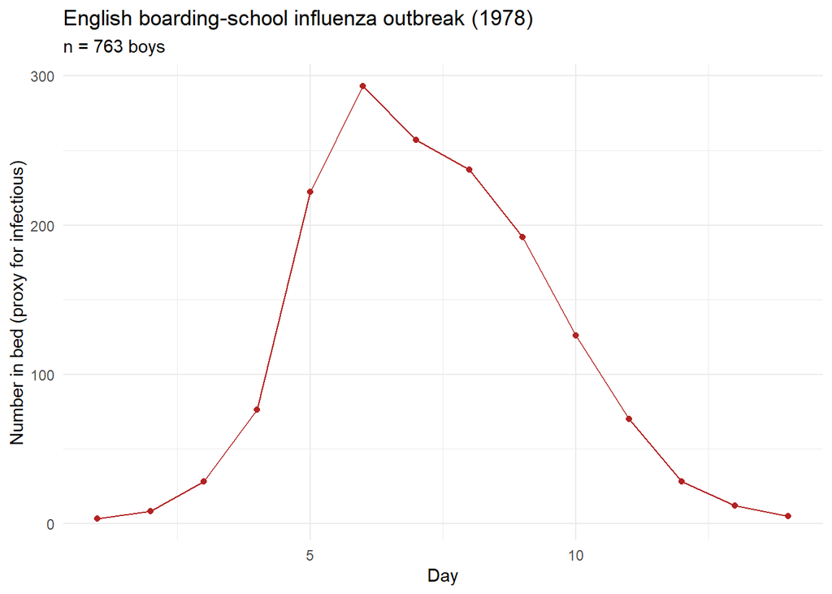

```r
library(ggplot2)

boarding_school_flu <- data.frame(
  day = 1:14,
  in_bed = c(3, 8, 28, 76, 222, 293, 257, 237, 192, 126, 70, 28, 12, 5)
)

#saving this for later...
Plot_school <- ggplot(boarding_school_flu, aes(x = day, y = in_bed)) +
  geom_line(colour = "firebrick") +
  geom_point(colour = "firebrick") +
  labs(title = "English boarding-school influenza outbreak (1978)",
       subtitle = "n = 763 boys",
       x = "Day", y = "Number in bed (proxy for infectious)") +
  theme_minimal()

Plot_school
```

We will use `n = 763` as our network size below, and this curve as a rough visual benchmark for the simulated epidemics.

## Part A: three comparable networks (provided, no modelling required)

1. Generate and plot three networks with `n=763` nodes and a `mean_degree_target` of `6` according to (a) an Erdos-Renyi model, (b) a Barabasi-Albert algorithm and (c) a Watts-Strogatz algorithm.

*Indication*: feel free to use the `sample_gnm()`, `sample_pa()` and `sample_smallworld()` functions from the `igraph` package.

```r
library(igraph)
library(ggraph)
library(tidygraph)
library(patchwork)
library(extrafont)
library(ggdist)
library(tidyverse)

# font_import()          # ~3 min,
# loadfonts(device = "win")

set.seed(21)

n <- 763
mean_degree <- 6
p <- mean_degree/n
m <- 3 #mean degree ~ 2m = 6, can alos use as nei in small world model: mean degree = 2* nei

g_er <- sample_gnp(n=n, p=p, directed = FALSE)
g_ba <- sample_pa(n=n, m=m, power = 1, directed  = FALSE)
g_ws <- sample_smallworld(size=n, dim = 1, nei = m, p = 0.1)

custom_palette <- c("#aa2323", "#54155d", "#1c6e3d", "#18246e" )
```

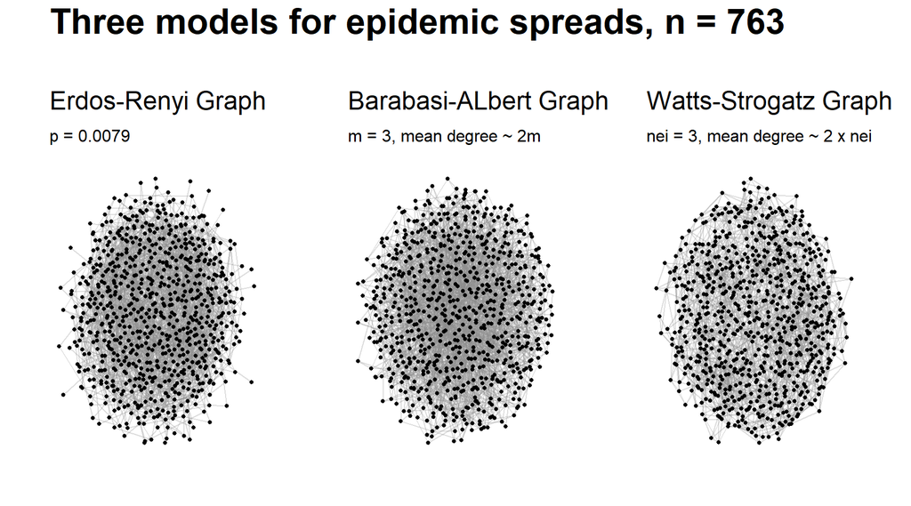

```r
Plot_ER <- ggraph(g_er, layout = "kk") +
  geom_edge_link0(edge_colour = "grey55", alpha = 0.3) +
  geom_node_point(size = 1) +
  theme_graph() +
  labs(title = "Erdos-Renyi Graph",
       subtitle = paste0("p = ", round(p,4))) +
  theme(plot.title = element_text(face='plain'))


Plot_BA <- ggraph(g_ba, layout = "kk") +
  geom_edge_link0(edge_colour = "grey55", alpha = 0.3) +
  geom_node_point(size = 1) +
  theme_graph() +
  labs(title = "Barabasi-ALbert Graph",
       subtitle = "m = 3, mean degree ~ 2m") +
  theme(plot.title = element_text(face='plain'))

Plot_WS <- ggraph(g_ws, layout = "kk") +
  geom_edge_link0(edge_colour = "grey55", alpha = 0.3) +
  geom_node_point(size = 1) +
  theme_graph() +
  labs(title = "Watts-Strogatz Graph",
       subtitle = "nei = 3, mean degree ~ 2 x nei") +
  theme(plot.title = element_text(face='plain'))

#===== produce the plot =====#

(Plot_ER | Plot_BA | Plot_WS) +
  plot_annotation(
    title = "Three models for epidemic spreads, n = 763",
    theme = theme(plot.title = element_text(size = 25, face = 'bold'))
  )
```

2. Also plot compare the degree distribution of the three networks and comment briefly (3-5 sentences).

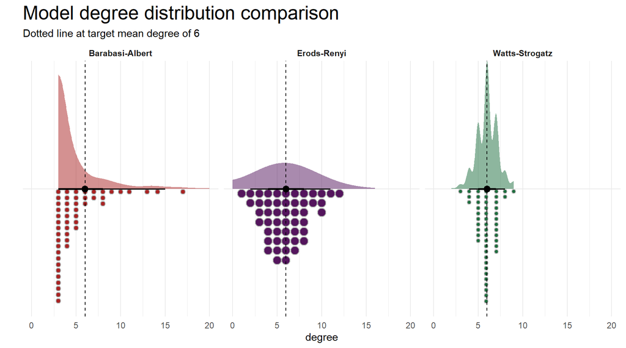

```r
degree_df <- bind_rows( #issue with render otherwise
  g_er %>% as_tbl_graph() %>%
    activate(nodes) %>%
    mutate(degree = centrality_degree()) %>%
    as_tibble() %>%
    mutate(model = 'Erods-Renyi'),
  g_ba %>% as_tbl_graph() %>%
    activate(nodes) %>%
    mutate(degree = centrality_degree()) %>%
    as_tibble() %>%
    mutate(model = 'Barabasi-Albert'),
  g_ws %>% as_tbl_graph() %>%
    activate(nodes) %>%
    mutate(degree = centrality_degree()) %>%
    as_tibble() %>%
    mutate(model = 'Watts-Strogatz'))

degree_df %>%
  ggplot(aes(y = '', x = degree, fill = model)) +
  stat_halfeye(scale = 1, adjust = 4, .width = 0, alpha = 0.5, point_colour = NA) +
  stat_dotsinterval(side = 'left', quantiles = 50, show_point = FALSE) +
  #stat summary had a bug, so annotate exactly
  annotate("point", x = mean(degree(g_ba)), y = '', size = 3, colour = "black") +
  geom_vline(aes(xintercept = 6), linetype = 'dashed') +
  facet_wrap(~ model) +
  scale_x_continuous(limits = c(0,20)) +
  scale_fill_manual(values = custom_palette) +
  labs( y = "",
        title = "Model degree distribution comparison",
        subtitle = "Dotted line at target mean degree of 6") +
  theme_minimal() +
  theme(legend.position = 'none',
        plot.title = element_text(size =20),
        strip.text = element_text(face = 'bold'))
```

All models have the target mean degree. The Erdos-Renyi graph has an almost normal distribution, which is expected given that every edge is placed with independent probability and this model has a poisson distribution which tends to a normal distribution for large n. The Barabasi-Albert graph has a right skewed distribution, which again is expected because the preferential attachment model means a few, early nodes get most of the attachments, and hence have a higher degree - it follows a power law distribution. While the Watt-Strogatz model has a very peaked distribution centred around the mean degree of 6. Most nodes are of a similar degree with a high peak, and looks like rapid decrease out to the edges, so perhaps exponential decay.

## Part B: does an epidemic spread the same way on each network? (your main task)

The `simulate_sir_network()` function below runs a simple discrete-time SIR-type process on any `igraph` network: each infected node infects each susceptible neighbour with probability `beta` per step, then recovers with probability `gamma`. It is provided for you.

```r
simulate_sir_network <- function(g, beta, gamma, n_infected_init = 1,
                                  n_steps = 100, seed = NULL) {
  if (!is.null(seed)) set.seed(seed)
  n <- vcount(g)
  status <- rep("S", n)
  status[sample(seq_len(n), n_infected_init)] <- "I"

  out <- data.frame(day = seq_len(n_steps), S = NA, I = NA, R = NA)

  for (t in seq_len(n_steps)) {
    infected_nodes <- which(status == "I")
    if (length(infected_nodes) == 0) {
      out[t:n_steps, c("S", "I", "R")] <-
        matrix(c(sum(status == "S"), 0, sum(status == "R")),
               nrow = n_steps - t + 1, ncol = 3, byrow = TRUE)
      break
    }

    new_infected <- integer(0)
    for (node in infected_nodes) {
      nb <- neighbors(g, node)
      sus_nb <- nb[status[nb] == "S"]
      if (length(sus_nb) > 0) {
        newly <- sus_nb[runif(length(sus_nb)) < beta]
        new_infected <- union(new_infected, as.integer(newly))
      }
    }
    recovers <- infected_nodes[runif(length(infected_nodes)) < gamma]

    status[new_infected] <- "I"
    status[recovers] <- "R"

    out$S[t] <- sum(status == "S")
    out$I[t] <- sum(status == "I")
    out$R[t] <- sum(status == "R")
  }
  out
}
```

Now it’s your turn. Using `simulate_sir_network()`:

3. Run the simulation on the three networks you have created in Part A, with the **same** `beta`, `gamma`, `n_infected_init` and `seed`, so the only thing that differs is network structure. (but feel free to explore different parameters?!)
4. Combine the three results into a unique data frame (add a `model` column).
5. Plot the number infected `I` over time for all three models on the same axes, so they are directly comparable.
6. Compare against the real boarding-school curve above (informally is fine: same rough shape? faster/slower? bigger/smaller peak?).

```r
beta <- 0.15
gamma <- 0.2
n_steps <- 60
n_infected_init <- 3 # I match the #(initial real cases)
seed <- 21

sir_er <- simulate_sir_network(g_er, beta = beta, gamma = gamma, n_infected_init = n_infected_init, n_steps = n_steps, seed = seed)
sir_ba <- simulate_sir_network(g_ba, beta = beta, gamma = gamma, n_infected_init = n_infected_init, n_steps = n_steps, seed = seed)
sir_ws <- simulate_sir_network(g_ws, beta = beta, gamma = gamma, n_infected_init = n_infected_init, n_steps = n_steps, seed = seed)

sir_all <- rbind(
  cbind(sir_er, model = "ER"),
  cbind(sir_ba, model = "BA"),
  cbind(sir_ws, model = "WS")
)
```

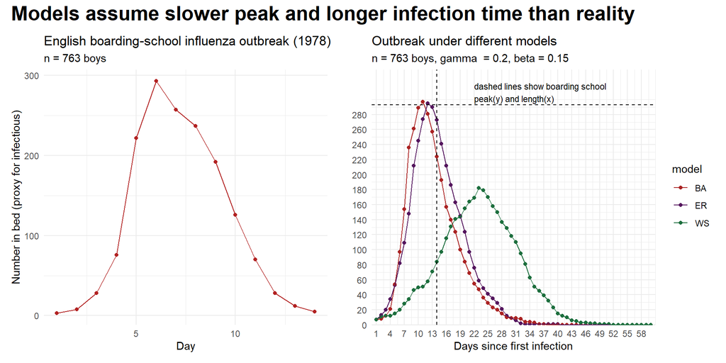

```r
Plot_sir <- sir_all %>%
  ggplot(aes(col = model, x = day, y = I)) +
  geom_point() +
  geom_line() +
  geom_hline(aes(yintercept = 293), linetype ='dashed') +
  geom_vline(aes(xintercept = 14), linetype ='dashed') +
  annotate("text", x = 22, y = 310, label = "dashed lines show boarding school\npeak(y) and length(x)", hjust = 0, size = 3) +
  scale_colour_manual(values = custom_palette) +
  scale_y_continuous(breaks = seq(min(sir_all$I), max(sir_all$I), by = 20),
                     limits = c(0, 340),
                     expand = expansion(mult = 0, add = 0)) +
  scale_x_continuous(breaks = seq(min(sir_all$day), max(sir_all$day), by = 3),
                     limits = c(1, 60),
                     expand = expansion(mult = 0, add = 1)) +
  labs(
    title = "Outbreak under different models",
    subtitle = "n = 763 boys, gamma  = 0.2, beta = 0.15",
    y = "",
    x = "Days since first infection") +
  theme_minimal()


(Plot_school | Plot_sir) +
  plot_annotation(title = 'Models assume slower peak and longer infection time than reality',
                  theme = theme(plot.title = element_text(size = 20, face = 'bold')))
```